# Fun T20 cricket analysis

Sayani Gupta

12/07/2019

Let us imagine a T20 format of cricket to be in a calendar format, where each ball is assumed to represent an unit of time. In such a world, a calendar would look like the following:

hour : ball  
day: over  
quarter: 5 overs  
semester: 10 overs  
year: 20 overs

Suppose, we are interested to see how the distribution of scores vary from the start to the end of the game. Let us brainstorm some of the questions that might help us comprehend that.

1. How the score varies across each balls, over, quarter or semester of the game for the number of matches played.

For example, if the team has played 5 T20 matches and we are interested to know how scores varied for each of those 20*5 = 100 overs, then what we are trying to understand here is the distribution of scores across linear categorization, overs in this case.

2. How the scores vary per each over of a quarter, or each quarter of a semester each over of a semester?

We are essentially trying to understand the distribution of scores across periodic categorisations, where each coarser unit consists of equal number of finer units for all levels of the coarser unit. For each match, balls, overs, quarters and semesters can be thought to align linearly where balls vary from 1,2, ..120, overs vary from 1, 2, …20, quarters range from 1, 2,…,4 and so on. We call these “linear” categorisation if we are just looking at one match.But for 80 matches, these are not “linear” since they keep on repeating themselves within a match. We call these “circular” categorisations. Similarly, we can also be interested to study the distribution of runs across balls per over/quarter/semester, overs per quarter/semester and quarters per semester.

What are the exhaustive list of circular categorisation that we can look at here:

1. balls of an over (ball_over)
2. balls of a quarter (ball_quarter)
3. balls of a semester (ball_semester)
4. balls of a match (ball_match)
5. overs of a quarter (ball_quarter)
6. overs of a semester (over_semester)
7. overs of a match (over_match)
8. quarters of a semester (quarter_semester)
9. quarters of a match (quarter_match)
10. semesters of a match (semester_match)

The hierarchy being as follows -

- ball
- over -> 6 balls
- quarter -> 5 overs
- semester -> 2 quarters
- match -> 2 semesters

```r
hierarchy_model <- tibble(category_ls = c("ball", "over", "quarter", "semester", "match"), conversion_fac  = c(6, 5, 2, 2, 1))
hierarchy_model
```

```
## # A tibble: 5 x 2
##   category_ls conversion_fac
##   <chr>                <dbl>
## 1 ball                     6
## 2 over                     5
## 3 quarter                  2
## 4 semester                 2
## 5 match                    1
```

### [Dataset: Indian Premier League (IPL) ball by ball](https://www.kaggle.com/littleraj30/indian-premier-league-2019-ball-by-ball)

We will look at the ball by ball data for Mumbai Indians. Performance will vary depending on if they are batting 1st or 2nd. Hence, it is a good idea to filter the matches in which they have batted first.

```r
# reading ball by ball data
data <-  read_csv("deliveries.csv")
data_MI <- data %>%
  filter(batting_team =="Mumbai Indians", inning ==1) %>%
  mutate(quarter_match = case_when(

    between(over,1,5) ~ 1,
    between(over,6,10) ~ 2,
    between(over,11,15) ~ 3,
    between(over,16,20) ~ 4
  )) %>%
   mutate(semester_match = case_when(

    between(quarter_match,1,2) ~ 1,
    between(quarter_match,3,4) ~ 2
  ))  %>%
   mutate(over_quarter =
  if_else(over%%5==0,5, over%%5)
   ) %>%  mutate(quarter_semester =
  if_else(quarter_match%%2==0,2, quarter_match%%2)
   )
```

```r
data_MI %>% distinct(match_id) %>% nrow()
```

```
## [1] 82
```

# Checking data accuracy

```r
data_MI %>% distinct(over) %>% nrow()
```

```
## [1] 20
```

```r
data_MI %>% distinct(ball) %>% range()
```

```
## [1] 1 9
```

```r
data_MI %>% distinct(total_runs) %>% range()
```

```
## [1] 0 7
```

Each match consists of 20 overs. Total runs per ball ranges from 0 to 7, which also seems sensible. Balls per over ranges from 1 to 9, which seems reasonable in case of no/wide balls. However, we would eliminate such cases so that each over consists of 6 balls. There are 2 matches for which some overs have less than 6 balls. These 2 matches are removed from the dataset. Also rows for which (wide_runs + noball_runs) not equal to zero are removed from the dataset. This would ensure that each over has 6 balls. However, in the dataset the ball index will still range from 1 to 9. The ball index is renamed from 1 to 6 based on the rank. Thus a over in the dataset which has balls (1, 3, 5, 6, 8, 9) will be renamed as (1, 2, 3, 4, 5, 6) so that ball labels are consistent across overs.

```r
match_er <- data_MI %>% filter(wide_runs + noball_runs==0) %>% group_by(match_id,over) %>%  summarize(n = n()) %>% filter(n!=6) %>% select(match_id)

nmatch = data_MI$match_id %>% length()
nover = data_MI %>% distinct(over) %>% nrow()

data_MI <- data_MI %>% filter(!match_id  %in% match_er$match_id, wide_runs + noball_runs==0) %>%
  mutate(balls = purrr::rep_along(match_id, 1:6),
         balls_game =  purrr::rep_along(match_id, 1:120)) %>%
  select(match_id, over, balls, balls_game,  quarter_match, semester_match,  total_runs, over_quarter, quarter_semester)


#data_MI %>% group_by(match_id, over) %>% summarise(n = n()) %>% distinct()
```

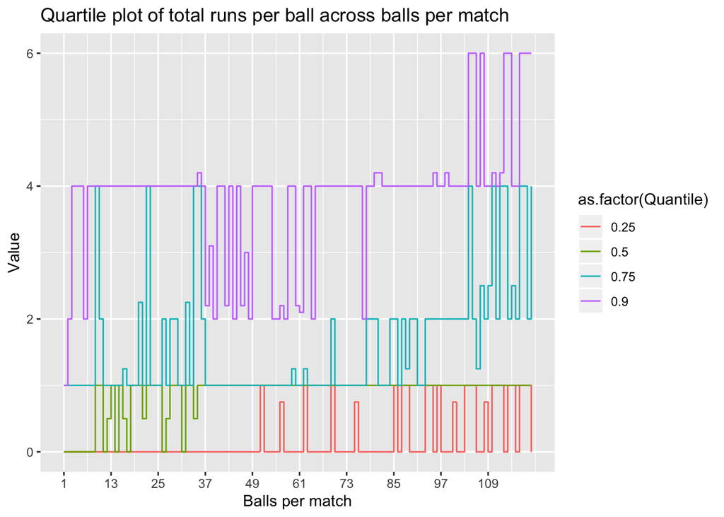

```r
# data_MI %>% ggplot(aes(x = as.factor(balls_game), y= total_runs)) +  geom_boxplot()+ xlab("balls")
# data_MI %>% ggplot(aes(y = as.factor(balls_game), x= total_runs)) + geom_density_ridges2() + ylab("Balls per  over")


data_MI_dec <- data_MI %>%
  group_by(balls_game) %>%
  do({x <- .$total_runs
  map_dfr(.x = c(0.25,0.5, 0.75, 0.9),
          .f = ~ tibble(Quantile = .x,
                            Value = quantile(x, probs = .x,na.rm=TRUE)))
  })


data_MI_dec %>%
  ggplot(aes(x = balls_game,y = Value,col = as.factor(Quantile))) +
  geom_step() +
  xlab("Balls per match") + scale_x_continuous(breaks = seq(1, 120, 12)) +
  ggtitle("Quartile plot of total runs per ball across balls per match")
```

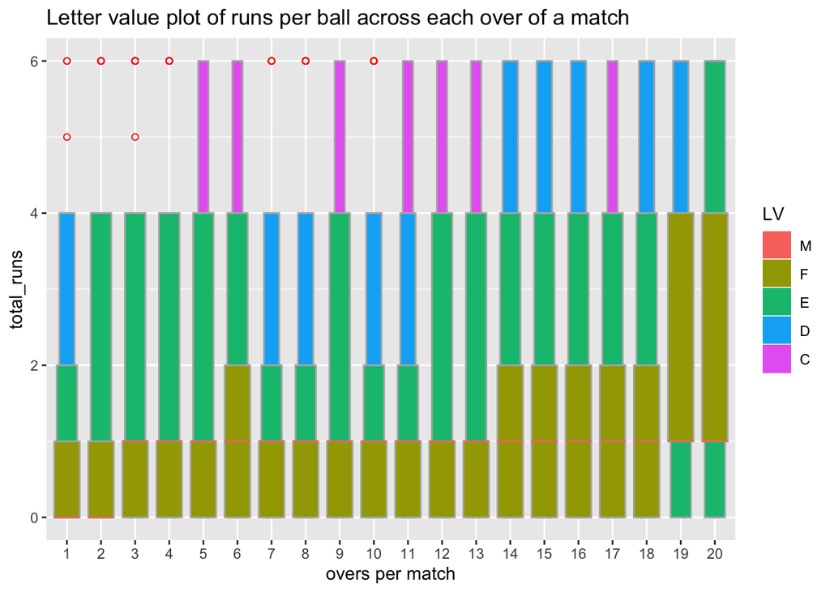

```r
data_MI %>% ggplot(aes(x = as.factor(over), y= total_runs)) + ggtitle("Letter value plot of runs per ball across each over of a match") + geom_lv(aes(fill = ..LV..), outlier.colour = "red", outlier.shape = 1, k = 5) + xlab("overs per match")
```

```r
# data_MI %>% ggplot(aes(y =as.factor(over), x= total_runs)) + geom_density_ridges2() + ylab("Balls per  over")
```

In the first two overs, players play really safe and make no runs 50% of the times. The median is constant at 1 for all overs after the 2nd over. It is interesting to see the distribution of tails in this plot. M, F, E, D and C represents 50%, 25%, 12.5%, 6.25% and 3.13% of the tail area respectively. Till the first four overs, scoring a 4 or a 6 is extreme. The region which covers the tail 3.13% falls between 4 and 6 till up to 13th over. It is interesting to see how the letter values of scores (D, E and F) moves up, as we move towards the end of the game.

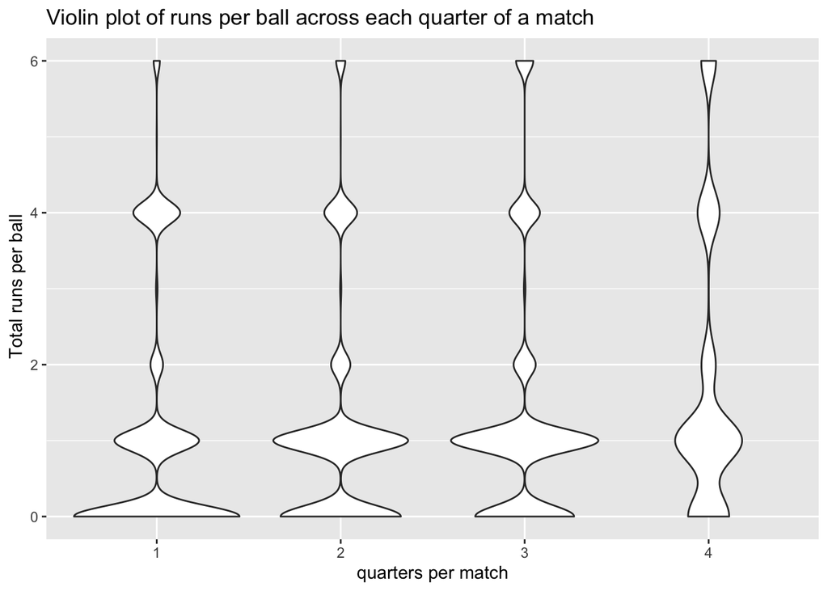

```r
data_MI %>% ggplot(aes(x = as.factor(quarter_match), y= total_runs)) +  geom_violin()+ xlab("quarters per match")+ ylab(" Total runs per ball") + ggtitle("Violin plot of runs per ball across each quarter of a match")
```

```r
# data_MI %>% ggplot(aes(y =as.factor(quarter), x= total_runs)) + geom_density_ridges2() + ylab("quarters per match") + xlab(" Total runs per ball")
```

4th quarter of the match witnesses low density(mass) at scores 0, 1 and more at 4/6. The density at score 6 increases with the quarters of the match.

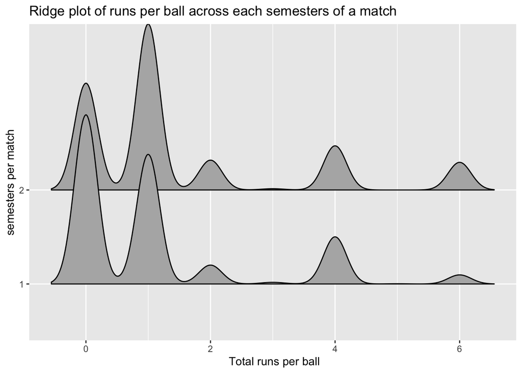

```r
# data_MI %>% ggplot(aes(x = as.factor(semester_match), y= total_runs)) +  geom_violin()+ xlab("semester per match")+ ylab(" Total runs per ball") +ggtitle("Violin plot of runs per ball across each semesters of a match")

data_MI %>% ggplot(aes(x = total_runs, y= as.factor(semester_match))) +  geom_density_ridges2()+ ylab("semesters per match")+ xlab(" Total runs per ball")+ ggtitle("Ridge plot of runs per ball across each semesters of a match")
```

```r
# data_MI %>% ggplot(aes(y =as.factor(semester), x= total_runs, fill=factor(..quantile..))) +   stat_density_ridges(
#     geom = "density_ridges_gradient", calc_ecdf = TRUE,
#     quantiles = 4, quantile_lines = TRUE
#   )  + ylab("semester") + xlab(" Total runs per ball") +
#   scale_fill_viridis(discrete = TRUE, name = "Quartiles")
```

Now, it will be interesting to see the distribution of runs per ball across two categorisation together:

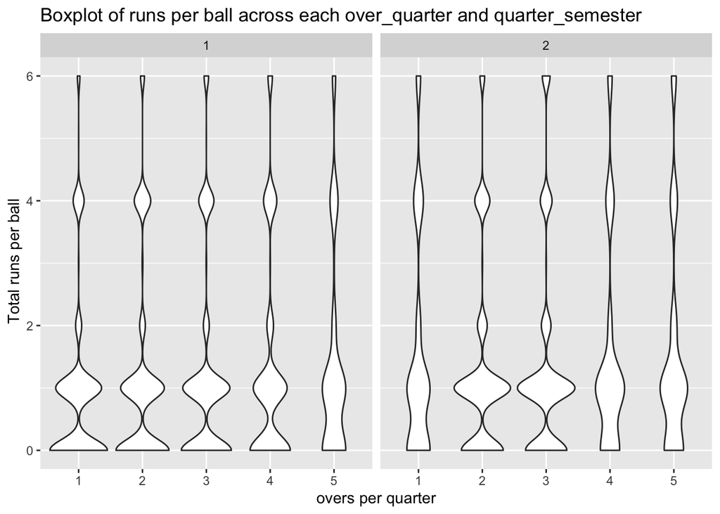

```r
# data_MI %>% ggplot(aes(x = as.factor(semester_match), y= total_runs)) +  geom_violin()+ xlab("semester per match")+ ylab(" Total runs per ball") +ggtitle("Violin plot of runs per ball across each semesters of a match")

data_MI %>% ggplot(aes(x = as.factor(over_quarter), y = total_runs))+  geom_violin()+
                     facet_wrap(~quarter_semester) + xlab("overs per quarter")+ ylab(" Total runs per ball") + ggtitle("Boxplot of runs per ball across each over_quarter and quarter_semester")
```

WIP